# Simulation 2 - non-probability sample

## 1 Libraries and functions

Load libraries and functions

```r
library(sampling)
library(laeken)
library(survey)
library(data.table)
library(ggplot2)
library(scales)
library(Rcpp)
source("../functions.R") ## to be replaced by package
```

PPS sampling function

```r
sourceCpp("syspps.cpp")
```

## 2 Simulate data

- population size $N=20,000$
- probability sample $B$ is of size $1000$
- non-probability sample $A$ is of size $1000$
- auxiliary variables $x$ are generated as follows:
  - $z_{1 i} \sim \operatorname{Bernoulli}(0.5)$
  - $z_{2 i} \sim \operatorname{Uniform}(0,2)$
  - $z_{3 i} \sim \operatorname{Exponential}(1)$
  - $z_{4 i} \sim \chi^{2}(4)$
  - $x_{1 i}=z_{1i}$
  - $x_{2 i}=z_{2 i}+0.3 x_{1 i}$
  - $x_{3 i}=z_{3 i}+0.2(x_{1 i}+x_{2 i})$
  - $x_{4 i}=z_{4 i}+0.1(x_{1 i}+x_{2 i}+x_{3 i})$
- target varible $y$ is generated using the following linear model

$$y_{i}=2+x_{1 i}+x_{2 i}+x_{3 i}+x_{4 i}+\sigma \varepsilon_{i}, \quad i=1,2, \ldots, N$$

where $\varepsilon_{i}$ ’s are independent and identically distributed (iid) as $N(0,1)$,

where $\theta_{0}$ is chosen such that $\sum_{i=1}^{N} \pi_{i}^{\mathrm{A}}=n_{\mathrm{A}}$ with the given target sample size $n_{\mathrm{A}}$.

- The nonprobability sample $A$ is selected by the Poisson sampling method with inclusion probabilities specified by $\pi_{i}^A$ and the target sample size $n_A$.
- The probability sample $B$ with the target size $n_B$ is taken by the randomized systematic PPS sampling method with the inclusion probabilities $\pi_{i}^B$ proportional to $z_{i}=c+x_{3 i}$. The value of $c$ is chosen to control the variation of the survey weights such that $\max z_{i} / \min z_{i}=50$.

Design:

1. known population totals and quantiles
2. estimated population totals and quantiles

```r
seed_for_sim <- 2023-07-10
n_reps <- 2000
```

```r
set.seed(seed_for_sim+1)
N <- 20000
n_1 <- 1000
n_2 <- 1000
z1 <- rbinom(N, 1, 0.5)
z2 <- runif(N,0,2)
z3 <- rexp(N,1)
z4 <- rchisq(N, 4)
x1 <- z1
x2 <- z2 + 0.3*z1
x3 <- z3 + 0.2*(x1 + x2)
x4 <- z4 + 0.1*(x1 + x2 + x3)
e <- rnorm(N)

etol <- 1e-8
sigma03 <- stats::uniroot(f = function(s) cor(2+x1+x2+x3+x4, 2+x1+x2+x3+x4+s*e) - 0.3, c(0,20), tol = etol)$root
sigma05 <- stats::uniroot(f = function(s) cor(2+x1+x2+x3+x4, 2+x1+x2+x3+x4+s*e) - 0.5, c(0,20), tol = etol)$root
sigma08 <- stats::uniroot(f = function(s) cor(2+x1+x2+x3+x4, 2+x1+x2+x3+x4+s*e) - 0.8, c(0,20), tol = etol)$root

y1 <- 2+x1+x2+x3+x4+sigma03*e
y2 <- 2+x1+x2+x3+x4+sigma05*e
y3 <- 2+x1+x2+x3+x4+sigma08*e

theta_A1 <- stats::uniroot(f = function(s) sum(plogis(s + 0.1*x1+0.2*x2+0.3*x3+0.2*x4))-n_1, c(-20,0), tol = etol)$root
theta_A2 <- stats::uniroot(f = function(s) sum(plogis(s + 0.1*x1+0.2*x2+0.3*x3+0.2*x4))-n_2, c(-20,0), tol = etol)$root

pA_1 <- plogis(theta_A1 + 0.1*x1+0.2*x2+0.3*x3+0.2*x4)
w_pA_1 <- 1/pA_1
pA_2 <- plogis(theta_A2 + 0.1*x1+0.2*x2+0.3*x3+0.2*x4)
w_pA_2 <- 1/pA_2

s_B <- stats::uniroot(f = function(s) max(s+x3)/min(s+x3) - 50, c(0, 100), tol = etol)$root
pB_1 <- inclusionprobabilities(s_B + x3, n_1)
pB_2 <- inclusionprobabilities(s_B + x3, n_2)
w_pB_1 <- 1/pB_1
w_pB_2 <- 1/pB_2

pop_data <- data.frame(x1,x2,x3,x4,y1,y2,y3,pA_1,pA_2,w_pA_1,w_pA_2,pB_1,pB_2,w_pB_1,w_pB_2) |> setDT()
head(pop_data)
```

| x1 | x2 | x3 | x4 | y1 | y2 | y3 | pA_1 | pA_2 | w_pA_1 | w_pA_2 | pB_1 | pB_2 | w_pB_1 | w_pB_2 |
| --- | --- | --- | --- | --- | --- | --- | --- | --- | --- | --- | --- | --- | --- | --- |
| 1 | 2.0398881 | 2.3423275 | 4.100387 | 31.499564 | 22.510618 | 16.295204 | 0.0646468 | 0.0646468 | 15.46867 | 15.46867 | 0.0839763 | 0.0839763 | 11.908120 | 11.908120 |
| 0 | 1.3243507 | 0.5244199 | 6.422652 | -3.006947 | 2.955923 | 7.078955 | 0.0476063 | 0.0476063 | 21.00561 | 21.00561 | 0.0238676 | 0.0238676 | 41.897759 | 41.897759 |
| 0 | 0.7606242 | 4.5634290 | 2.888292 | 6.369412 | 8.095144 | 9.288403 | 0.0688861 | 0.0688861 | 14.51671 | 14.51671 | 0.1574165 | 0.1574165 | 6.352574 | 6.352574 |
| 1 | 1.1061130 | 0.9717368 | 9.098352 | 19.422176 | 17.066385 | 15.437471 | 0.0936106 | 0.0936106 | 10.68255 | 10.68255 | 0.0386581 | 0.0386581 | 25.867831 | 25.867831 |
| 0 | 0.4031535 | 1.7636402 | 6.149681 | 19.821910 | 15.553338 | 12.601830 | 0.0540091 | 0.0540091 | 18.51539 | 18.51539 | 0.0648422 | 0.0648422 | 15.422067 | 15.422067 |
| 0 | 0.8462334 | 0.3288437 | 2.365348 | 18.840762 | 12.868027 | 8.738174 | 0.0186741 | 0.0186741 | 53.55024 | 53.55024 | 0.0174009 | 0.0174009 | 57.468138 | 57.468138 |

## 3 Known population totals and quantiles

```r
x_totals <- with(pop_data, c(sum(x1), sum(x2), sum(x3), sum(x4)))
p_quantiles <- seq(0.25, 0.75, 0.25)
x2_q <- with(pop_data, quantile(x2, p_quantiles))
x3_q <- with(pop_data, quantile(x3, p_quantiles))
x4_q <- with(pop_data, quantile(x4, p_quantiles))
```

```r
pop_true_vals <- pop_data[, lapply(.SD,
                                   function(x) data.frame(m=mean(x),
                                                          q25=quantile(x, 0.25),
                                                          q50=quantile(x, 0.5),
                                                          q75=quantile(x, 0.75))),
                          .SDcols = c("y1", "y2", "y3")] |>
  melt(value.name = "true") |>
  {\(x) x[, c("y", "estimator") := tstrsplit(variable, "\\.")][, .(y, estimator, true)]}()
pop_true_vals
```

| y | estimator | true |
| --- | --- | --- |
| y1 | m | 9.243684 |
| y1 | q25 | 2.097755 |
| y1 | q50 | 9.185405 |
| y1 | q75 | 16.348845 |
| y2 | m | 9.233275 |
| y2 | q25 | 4.902847 |
| y2 | q50 | 9.125728 |
| y2 | q75 | 13.390259 |
| y3 | m | 9.226078 |
| y3 | q25 | 6.456686 |
| y3 | q50 | 8.902600 |
| y3 | q75 | 11.622890 |

```r
results_y3 <- results_y2 <- results_y1 <- matrix(data=0, nrow = n_reps, ncol = (1+length(p_quantiles))*4+1)
```

```r
for (r in 1:n_reps) {
  set.seed(r)
  sample_nonprob <- pop_data[which(sampling::UPpoisson(pop_data$pA_1)==1),]
  sample_nonprob$w_naive <- N/n_1

  w_res <- calib_quantiles(X_q = with(sample_nonprob, cbind(x2, x3, x4)),
                            d = sample_nonprob$w_naive,
                            N=N,
                            totals_q = list(x2_q, x3_q, x4_q),
                            method = "raking",
                            backend = "sampling")


  w_res2 <- calib_quantiles(X_q = with(sample_nonprob, cbind(x2, x3, x4)),
                           X =  with(sample_nonprob, cbind(x1, x2, x3, x4)),
                           d = sample_nonprob$w_naive,
                           N=N,
                           totals = x_totals,
                           totals_q = list(x2_q, x3_q, x4_q),
                           method = "raking",
                           backend = "sampling")

  w_res_st <- calib(Xs = with(sample_nonprob, cbind(x1, x2, x3, x4)),
                    d = sample_nonprob$w_naive,
                    total = x_totals,
                    method = "raking")

  sample_nonprob$w_cal_q1 <- w_res$w
  sample_nonprob$w_cal_q2 <- w_res2$w
  sample_nonprob$w_cal_s <- sample_nonprob$w_naive*w_res_st

  results_y1[r, 1] <- r
  results_y1[r, 2] <- with(sample_nonprob, mean(y1))
  results_y1[r, 3] <- with(sample_nonprob, weighted.mean(y1, w_cal_s))
  results_y1[r, 4] <- with(sample_nonprob, weighted.mean(y1, w_cal_q1))
  results_y1[r, 5] <- with(sample_nonprob, weighted.mean(y1, w_cal_q2))
  results_y1[r, 6:8] <- with(sample_nonprob, quantile(y1, p_quantiles))
  results_y1[r, 9:11] <- with(sample_nonprob, weightedQuantile(y1, w_cal_s, p_quantiles))
  results_y1[r, 12:14] <- with(sample_nonprob, weightedQuantile(y1, w_cal_q1, p_quantiles))
  results_y1[r, 15:17] <- with(sample_nonprob, weightedQuantile(y1, w_cal_q2, p_quantiles))

  results_y2[r, 1] <- r
  results_y2[r, 2] <- with(sample_nonprob, mean(y2))
  results_y2[r, 3] <- with(sample_nonprob, weighted.mean(y2, w_cal_s))
  results_y2[r, 4] <- with(sample_nonprob, weighted.mean(y2, w_cal_q1))
  results_y2[r, 5] <- with(sample_nonprob, weighted.mean(y2, w_cal_q2))
  results_y2[r, 6:8] <- with(sample_nonprob, quantile(y2, p_quantiles))
  results_y2[r, 9:11] <- with(sample_nonprob, weightedQuantile(y2, w_cal_s, p_quantiles))
  results_y2[r, 12:14] <- with(sample_nonprob, weightedQuantile(y2, w_cal_q1, p_quantiles))
  results_y2[r, 15:17] <- with(sample_nonprob, weightedQuantile(y2, w_cal_q2, p_quantiles))

  results_y3[r, 1] <- r
  results_y3[r, 2] <- with(sample_nonprob, mean(y3))
  results_y3[r, 3] <- with(sample_nonprob, weighted.mean(y3, w_cal_s))
  results_y3[r, 4] <- with(sample_nonprob, weighted.mean(y3, w_cal_q1))
  results_y3[r, 5] <- with(sample_nonprob, weighted.mean(y3, w_cal_q2))
  results_y3[r, 6:8] <- with(sample_nonprob, quantile(y3, p_quantiles))
  results_y3[r, 9:11] <- with(sample_nonprob, weightedQuantile(y3, w_cal_s, p_quantiles))
  results_y3[r, 12:14] <- with(sample_nonprob, weightedQuantile(y3, w_cal_q1, p_quantiles))
  results_y3[r, 15:17] <- with(sample_nonprob, weightedQuantile(y3, w_cal_q2, p_quantiles))

}
```

Combine results

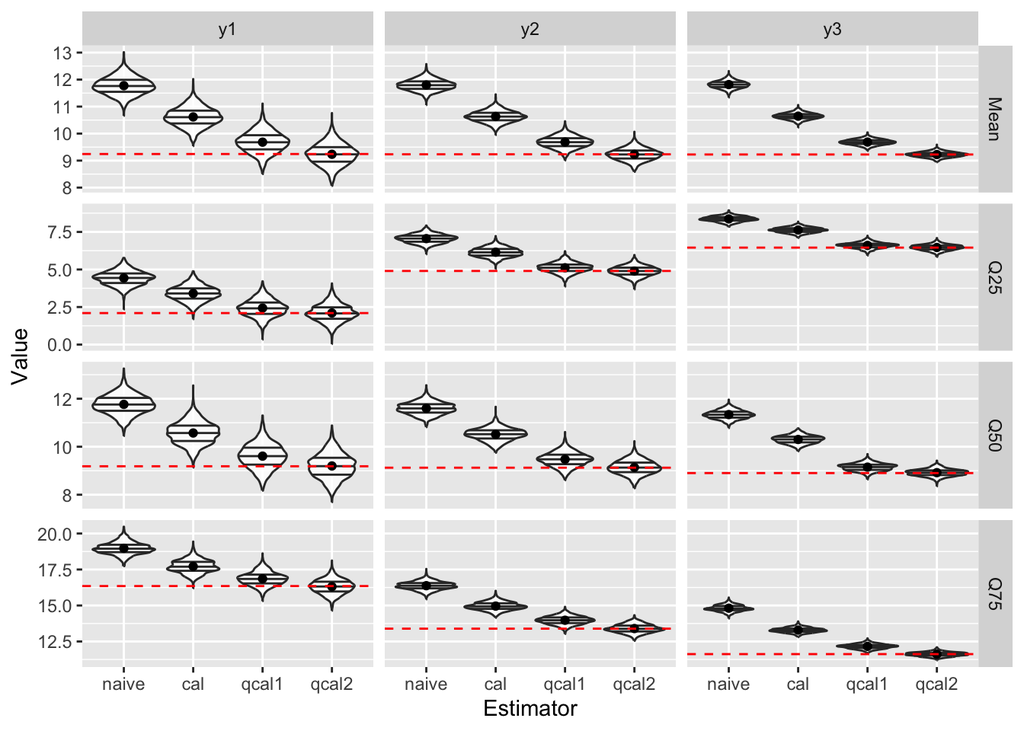

```r
results <- rbind(results_y1, results_y2, results_y3) |> as.data.frame() |> setDT()
setnames(results, names(results),
         c("iter", "m_naive", "m_cal", "m_qcal1", "m_qcal2",
           paste(paste0("q", rep(c(25, 50, 75), times = 4)), rep(c("naive", "cal", "qcal1", "qcal2"), each = 3), sep="_")))
results[, y:=rep(c("y1", "y2", "y3"), each = n_reps)]
results <- melt(results, id.vars = c("iter", "y"), value.name = "value", variable.name = "estimator")
results[, c("estimator", "type") := tstrsplit(estimator, "_")]
results <- results[pop_true_vals, on = c("y", "estimator")]
results[, type:= factor(type, c("naive", "cal", "qcal1", "qcal2"))]
results[, estimator:= factor(estimator, c("m", "q25", "q50", "q75"), c("Mean", "Q25", "Q50", "Q75"))]
pop_true_vals[, estimator2:= factor(estimator, c("m", "q25", "q50", "q75"), c("Mean", "Q25", "Q50", "Q75"))]

results |>
  ggplot(data = _, aes(x = type, y = value)) +
  #geom_jitter(alpha = 0.05, shape = 1) +
  geom_violin(alpha = 0.8, draw_quantiles = c(0.25, 0.5, 0.75)) +
  stat_summary(fun = mean, geom = "point") +
  facet_grid(estimator ~ y, scales = "free_y")  +
  geom_hline(data = pop_true_vals[, .(y, estimator=estimator2, true)],
             aes(yintercept = true), linetype = "dashed", color = "red") +
  labs(x = "Estimator", y = "Value")
```

```r
results[, .(mean = mean(value), bias=mean(value)-mean(true), var = var(value)), .(y, estimator, type)][
  , ":="(mse = bias^2+var, rmse = sqrt(bias^2+var))][order(y, estimator)]
```

| y | estimator | type | mean | bias | var | mse | rmse |
| --- | --- | --- | --- | --- | --- | --- | --- |
| y1 | Mean | naive | 11.774330 | 2.5306461 | 0.1055556 | 6.5097253 | 2.5514163 |
| y1 | Mean | cal | 10.617053 | 1.3733687 | 0.1218317 | 2.0079733 | 1.4170297 |
| y1 | Mean | qcal1 | 9.682710 | 0.4390254 | 0.1490392 | 0.3417825 | 0.5846217 |
| y1 | Mean | qcal2 | 9.233909 | -0.0097753 | 0.1553832 | 0.1554788 | 0.3943080 |
| y1 | Q25 | naive | 4.431694 | 2.3339391 | 0.2146349 | 5.6619064 | 2.3794761 |
| y1 | Q25 | cal | 3.408956 | 1.3112009 | 0.2534239 | 1.9726716 | 1.4045183 |
| y1 | Q25 | qcal1 | 2.430734 | 0.3329791 | 0.3170829 | 0.4279579 | 0.6541849 |
| y1 | Q25 | qcal2 | 2.103906 | 0.0061511 | 0.3233769 | 0.3234147 | 0.5686956 |
| y1 | Q50 | naive | 11.764434 | 2.5790292 | 0.1611269 | 6.8125188 | 2.6100802 |
| y1 | Q50 | cal | 10.571790 | 1.3863855 | 0.2085890 | 2.1306537 | 1.4596759 |
| y1 | Q50 | qcal1 | 9.607595 | 0.4221906 | 0.2604550 | 0.4387000 | 0.6623443 |
| y1 | Q50 | qcal2 | 9.198312 | 0.0129070 | 0.2599517 | 0.2601183 | 0.5100180 |
| y1 | Q75 | naive | 18.973619 | 2.6247745 | 0.1660827 | 7.0555239 | 2.6562236 |
| y1 | Q75 | cal | 17.717017 | 1.3681728 | 0.2006954 | 2.0725922 | 1.4396500 |
| y1 | Q75 | qcal1 | 16.857122 | 0.5082775 | 0.2235255 | 0.4818715 | 0.6941697 |
| y1 | Q75 | qcal2 | 16.311750 | -0.0370947 | 0.2409628 | 0.2423389 | 0.4922792 |
| y2 | Mean | naive | 11.798492 | 2.5652169 | 0.0413167 | 6.6216544 | 2.5732575 |
| y2 | Mean | cal | 10.633942 | 1.4006665 | 0.0415351 | 2.0034016 | 1.4154157 |
| y2 | Mean | qcal1 | 9.684517 | 0.4512413 | 0.0465807 | 0.2501994 | 0.5001994 |
| y2 | Mean | qcal2 | 9.227890 | -0.0053855 | 0.0471631 | 0.0471921 | 0.2172375 |
| y2 | Q25 | naive | 7.056620 | 2.1537732 | 0.0820075 | 4.7207465 | 2.1727279 |
| y2 | Q25 | cal | 6.149608 | 1.2467607 | 0.0961424 | 1.6505546 | 1.2847391 |
| y2 | Q25 | qcal1 | 5.116190 | 0.2133425 | 0.1106399 | 0.1561549 | 0.3951644 |
| y2 | Q25 | qcal2 | 4.890882 | -0.0119649 | 0.1131403 | 0.1132834 | 0.3365761 |
| y2 | Q50 | naive | 11.600089 | 2.4743606 | 0.0645012 | 6.1869613 | 2.4873603 |
| y2 | Q50 | cal | 10.513310 | 1.3875817 | 0.0668815 | 1.9922644 | 1.4114760 |
| y2 | Q50 | qcal1 | 9.475069 | 0.3493408 | 0.0872281 | 0.2092671 | 0.4574572 |
| y2 | Q50 | qcal2 | 9.139114 | 0.0133854 | 0.0845605 | 0.0847396 | 0.2911007 |
| y2 | Q75 | naive | 16.375959 | 2.9857000 | 0.0781075 | 8.9925121 | 2.9987518 |
| y2 | Q75 | cal | 14.957525 | 1.5672661 | 0.0776026 | 2.5339256 | 1.5918309 |
| y2 | Q75 | qcal1 | 13.974469 | 0.5842098 | 0.0799399 | 0.4212410 | 0.6490308 |
| y2 | Q75 | qcal2 | 13.398737 | 0.0084781 | 0.0843923 | 0.0844642 | 0.2906273 |
| y3 | Mean | naive | 11.815199 | 2.5891209 | 0.0190469 | 6.7225938 | 2.5927965 |
| y3 | Mean | cal | 10.645619 | 1.4195415 | 0.0133648 | 2.0284629 | 1.4242412 |
| y3 | Mean | qcal1 | 9.685766 | 0.4596880 | 0.0105256 | 0.2218386 | 0.4709975 |
| y3 | Mean | qcal2 | 9.223728 | -0.0023502 | 0.0089819 | 0.0089874 | 0.0948020 |
| y3 | Q25 | naive | 8.367598 | 1.9109118 | 0.0312176 | 3.6828013 | 1.9190626 |
| y3 | Q25 | cal | 7.628928 | 1.1722425 | 0.0296734 | 1.4038259 | 1.1848316 |
| y3 | Q25 | qcal1 | 6.602724 | 0.1460379 | 0.0363802 | 0.0577073 | 0.2402234 |
| y3 | Q25 | qcal2 | 6.464766 | 0.0080803 | 0.0353008 | 0.0353661 | 0.1880586 |
| y3 | Q50 | naive | 11.338744 | 2.4361439 | 0.0315335 | 5.9663307 | 2.4426074 |
| y3 | Q50 | cal | 10.302078 | 1.3994779 | 0.0276058 | 1.9861442 | 1.4093063 |
| y3 | Q50 | qcal1 | 9.148149 | 0.2455490 | 0.0241387 | 0.0844330 | 0.2905737 |
| y3 | Q50 | qcal2 | 8.919342 | 0.0167423 | 0.0211171 | 0.0213974 | 0.1462784 |
| y3 | Q75 | naive | 14.812278 | 3.1893880 | 0.0462202 | 10.2184160 | 3.1966257 |
| y3 | Q75 | cal | 13.290032 | 1.6671423 | 0.0276736 | 2.8070370 | 1.6754214 |
| y3 | Q75 | qcal1 | 12.159523 | 0.5366334 | 0.0269767 | 0.3149521 | 0.5612059 |
| y3 | Q75 | qcal2 | 11.615609 | -0.0072803 | 0.0200417 | 0.0200947 | 0.1417557 |

## 4 Estimated population totals and quantiles

```r
results_y3_sample <- results_y2_sample <- results_y1_sample <- matrix(data=0, nrow = n_reps, ncol = (1+length(p_quantiles))*4+1)
```

```r
for (r in 1:n_reps) {
  set.seed(r)
  sample_nonprob <- pop_data[which(sampling::UPpoisson(pop_data$pA_1)==1),]
  sample_nonprob$w_naive <- N/n_1
  sample_prob <- pop_data[syspps_cpp(pop_data$pB_1, n_1), ]
  sample_prob_svy <- svydesign(ids=~1, probs =~pB_1, data = sample_prob)

  q_est <- svyquantile( ~ x2 + x3 + x4, sample_prob_svy, p_quantiles)
  x_totals <- svytotal( ~ x1 + x2 + x3 + x4, sample_prob_svy) |> as.numeric()
  N_hat <- sum(weights(sample_prob_svy))

  w_res <- calib_quantiles(X_q = with(sample_nonprob, cbind(x2, x3, x4)),
                            d = sample_nonprob$w_naive,
                            N=N_hat,
                            totals_q = list(q_est$x2[, 1], q_est$x3[, 1], q_est$x4[, 1]),
                            method = "raking",
                            backend = "sampling")


  w_res2 <- calib_quantiles(X_q = with(sample_nonprob, cbind(x2, x3, x4)),
                           X =  with(sample_nonprob, cbind(x1, x2, x3, x4)),
                           d = sample_nonprob$w_naive,
                           N=N_hat,
                           totals = x_totals,
                           totals_q = list(q_est$x2[, 1], q_est$x3[, 1], q_est$x4[, 1]),
                           method = "raking",
                           backend = "sampling")

  w_res_st <- calib(Xs = with(sample_nonprob, cbind(x1, x2, x3, x4)),
                    d = sample_nonprob$w_naive,
                    total = x_totals,
                    method = "raking")

  sample_nonprob$w_cal_q1 <- w_res$w
  sample_nonprob$w_cal_q2 <- w_res2$w
  sample_nonprob$w_cal_s <- sample_nonprob$w_naive*w_res_st

  results_y1_sample[r, 1] <- r
  results_y1_sample[r, 2] <- with(sample_nonprob, mean(y1))
  results_y1_sample[r, 3] <- with(sample_nonprob, weighted.mean(y1, w_cal_s))
  results_y1_sample[r, 4] <- with(sample_nonprob, weighted.mean(y1, w_cal_q1))
  results_y1_sample[r, 5] <- with(sample_nonprob, weighted.mean(y1, w_cal_q2))
  results_y1_sample[r, 6:8] <- with(sample_nonprob, quantile(y1, p_quantiles))
  results_y1_sample[r, 9:11] <- with(sample_nonprob, weightedQuantile(y1, w_cal_s, p_quantiles))
  results_y1_sample[r, 12:14] <- with(sample_nonprob, weightedQuantile(y1, w_cal_q1, p_quantiles))
  results_y1_sample[r, 15:17] <- with(sample_nonprob, weightedQuantile(y1, w_cal_q2, p_quantiles))

  results_y2_sample[r, 1] <- r
  results_y2_sample[r, 2] <- with(sample_nonprob, mean(y2))
  results_y2_sample[r, 3] <- with(sample_nonprob, weighted.mean(y2, w_cal_s))
  results_y2_sample[r, 4] <- with(sample_nonprob, weighted.mean(y2, w_cal_q1))
  results_y2_sample[r, 5] <- with(sample_nonprob, weighted.mean(y2, w_cal_q2))
  results_y2_sample[r, 6:8] <- with(sample_nonprob, quantile(y2, p_quantiles))
  results_y2_sample[r, 9:11] <- with(sample_nonprob, weightedQuantile(y2, w_cal_s, p_quantiles))
  results_y2_sample[r, 12:14] <- with(sample_nonprob, weightedQuantile(y2, w_cal_q1, p_quantiles))
  results_y2_sample[r, 15:17] <- with(sample_nonprob, weightedQuantile(y2, w_cal_q2, p_quantiles))

  results_y3_sample[r, 1] <- r
  results_y3_sample[r, 2] <- with(sample_nonprob, mean(y3))
  results_y3_sample[r, 3] <- with(sample_nonprob, weighted.mean(y3, w_cal_s))
  results_y3_sample[r, 4] <- with(sample_nonprob, weighted.mean(y3, w_cal_q1))
  results_y3_sample[r, 5] <- with(sample_nonprob, weighted.mean(y3, w_cal_q2))
  results_y3_sample[r, 6:8] <- with(sample_nonprob, quantile(y3, p_quantiles))
  results_y3_sample[r, 9:11] <- with(sample_nonprob, weightedQuantile(y3, w_cal_s, p_quantiles))
  results_y3_sample[r, 12:14] <- with(sample_nonprob, weightedQuantile(y3, w_cal_q1, p_quantiles))
  results_y3_sample[r, 15:17] <- with(sample_nonprob, weightedQuantile(y3, w_cal_q2, p_quantiles))

}
```

Combine results

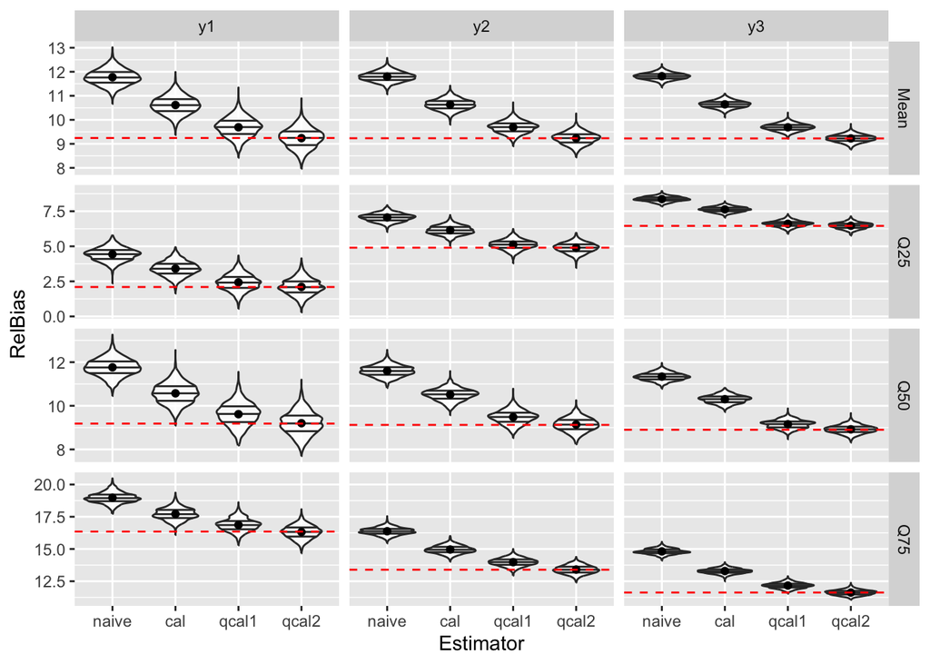

```r
results_sample <- rbind(results_y1_sample, results_y2_sample, results_y3_sample) |> as.data.frame() |> setDT()
setnames(results_sample, names(results_sample),
         c("iter", "m_naive", "m_cal", "m_qcal1", "m_qcal2",
           paste(paste0("q", rep(c(25, 50, 75), times = 4)),
                 rep(c("naive", "cal", "qcal1", "qcal2"), each = 3), sep="_")))

results_sample[, y:=rep(c("y1", "y2", "y3"), each = n_reps)]
results_sample <- melt(results_sample, id.vars = c("iter", "y"), value.name = "value", variable.name = "estimator")
results_sample[, c("estimator", "type") := tstrsplit(estimator, "_")]
results_sample <- results_sample[pop_true_vals, on = c("y", "estimator")]
results_sample[, type:= factor(type, c("naive", "cal", "qcal1", "qcal2"))]
results_sample[, estimator:= factor(estimator, c("m", "q25", "q50", "q75"), c("Mean", "Q25", "Q50", "Q75"))]

results_sample |>
  ggplot(data = _, aes(x = type, y = value)) +
  #geom_jitter(alpha = 0.05, shape = 1) +
  geom_violin(alpha = 0.8, draw_quantiles = c(0.25, 0.5, 0.75)) +
  stat_summary(fun = mean, geom = "point") +
  facet_grid(estimator ~ y, scales = "free_y")  +
    geom_hline(data = pop_true_vals[, .(y, estimator=estimator2, true)],
             aes(yintercept = true), linetype = "dashed", color = "red") +
  labs(x = "Estimator", y = "RelBias")
```

```r
results_sample[, .(mean = mean(value), bias=mean(value)-mean(true), var = var(value)), .(y, estimator, type)][
  , ":="(mse = bias^2+var, rmse = sqrt(bias^2+var))][order(y, estimator)]
```

| y | estimator | type | mean | bias | var | mse | rmse |
| --- | --- | --- | --- | --- | --- | --- | --- |
| y1 | Mean | naive | 11.774330 | 2.5306461 | 0.1055556 | 6.5097253 | 2.5514163 |
| y1 | Mean | cal | 10.617016 | 1.3733312 | 0.1308068 | 2.0168454 | 1.4201568 |
| y1 | Mean | qcal1 | 9.691005 | 0.4473211 | 0.1609114 | 0.3610075 | 0.6008390 |
| y1 | Mean | qcal2 | 9.238077 | -0.0056068 | 0.1704175 | 0.1704489 | 0.4128546 |
| y1 | Q25 | naive | 4.431694 | 2.3339391 | 0.2146349 | 5.6619064 | 2.3794761 |
| y1 | Q25 | cal | 3.408954 | 1.3111992 | 0.2625501 | 1.9817934 | 1.4077619 |
| y1 | Q25 | qcal1 | 2.428139 | 0.3303835 | 0.3306995 | 0.4398528 | 0.6632140 |
| y1 | Q25 | qcal2 | 2.105968 | 0.0082132 | 0.3384066 | 0.3384741 | 0.5817853 |
| y1 | Q50 | naive | 11.764434 | 2.5790292 | 0.1611269 | 6.8125188 | 2.6100802 |
| y1 | Q50 | cal | 10.572482 | 1.3870779 | 0.2197484 | 2.1437335 | 1.4641494 |
| y1 | Q50 | qcal1 | 9.616894 | 0.4314892 | 0.2756769 | 0.4618599 | 0.6796027 |
| y1 | Q50 | qcal2 | 9.202495 | 0.0170904 | 0.2770499 | 0.2773419 | 0.5266326 |
| y1 | Q75 | naive | 18.973619 | 2.6247745 | 0.1660827 | 7.0555239 | 2.6562236 |
| y1 | Q75 | cal | 17.716728 | 1.3678839 | 0.2100567 | 2.0811630 | 1.4426237 |
| y1 | Q75 | qcal1 | 16.866311 | 0.5174664 | 0.2412298 | 0.5090012 | 0.7134432 |
| y1 | Q75 | qcal2 | 16.315090 | -0.0337547 | 0.2574533 | 0.2585927 | 0.5085201 |
| y2 | Mean | naive | 11.798492 | 2.5652169 | 0.0413167 | 6.6216544 | 2.5732575 |
| y2 | Mean | cal | 10.633818 | 1.4005431 | 0.0501291 | 2.0116500 | 1.4183265 |
| y2 | Mean | qcal1 | 9.689994 | 0.4567191 | 0.0578575 | 0.2664498 | 0.5161877 |
| y2 | Mean | qcal2 | 9.231113 | -0.0021621 | 0.0612054 | 0.0612101 | 0.2474067 |
| y2 | Q25 | naive | 7.056620 | 2.1537732 | 0.0820075 | 4.7207465 | 2.1727279 |
| y2 | Q25 | cal | 6.149420 | 1.2465731 | 0.1012324 | 1.6551769 | 1.2865368 |
| y2 | Q25 | qcal1 | 5.116489 | 0.2136418 | 0.1213370 | 0.1669799 | 0.4086317 |
| y2 | Q25 | qcal2 | 4.892171 | -0.0106757 | 0.1261625 | 0.1262764 | 0.3553540 |
| y2 | Q50 | naive | 11.600089 | 2.4743606 | 0.0645012 | 6.1869613 | 2.4873603 |
| y2 | Q50 | cal | 10.512663 | 1.3869341 | 0.0748362 | 1.9984224 | 1.4136557 |
| y2 | Q50 | qcal1 | 9.481521 | 0.3557925 | 0.0987735 | 0.2253618 | 0.4747229 |
| y2 | Q50 | qcal2 | 9.139683 | 0.0139547 | 0.0972006 | 0.0973954 | 0.3120823 |
| y2 | Q75 | naive | 16.375959 | 2.9857000 | 0.0781075 | 8.9925121 | 2.9987518 |
| y2 | Q75 | cal | 14.958796 | 1.5685362 | 0.0904119 | 2.5507176 | 1.5970966 |
| y2 | Q75 | qcal1 | 13.979672 | 0.5894130 | 0.0942955 | 0.4417032 | 0.6646075 |
| y2 | Q75 | qcal2 | 13.403524 | 0.0132646 | 0.1023638 | 0.1025397 | 0.3202182 |
| y3 | Mean | naive | 11.815199 | 2.5891209 | 0.0190469 | 6.7225938 | 2.5927965 |
| y3 | Mean | cal | 10.645437 | 1.4193587 | 0.0217462 | 2.0363254 | 1.4269987 |
| y3 | Mean | qcal1 | 9.689295 | 0.4632173 | 0.0216482 | 0.2362185 | 0.4860232 |
| y3 | Mean | qcal2 | 9.226297 | 0.0002197 | 0.0228266 | 0.0228266 | 0.1510848 |
| y3 | Q25 | naive | 8.367598 | 1.9109118 | 0.0312176 | 3.6828013 | 1.9190626 |
| y3 | Q25 | cal | 7.628305 | 1.1716195 | 0.0330076 | 1.4056998 | 1.1856221 |
| y3 | Q25 | qcal1 | 6.603365 | 0.1466794 | 0.0471617 | 0.0686765 | 0.2620621 |
| y3 | Q25 | qcal2 | 6.465485 | 0.0087990 | 0.0459646 | 0.0460420 | 0.2145740 |
| y3 | Q50 | naive | 11.338744 | 2.4361439 | 0.0315335 | 5.9663307 | 2.4426074 |
| y3 | Q50 | cal | 10.301618 | 1.3990177 | 0.0350681 | 1.9923185 | 1.4114951 |
| y3 | Q50 | qcal1 | 9.152423 | 0.2498230 | 0.0362834 | 0.0986949 | 0.3141575 |
| y3 | Q50 | qcal2 | 8.921317 | 0.0187169 | 0.0335885 | 0.0339388 | 0.1842249 |
| y3 | Q75 | naive | 14.812278 | 3.1893880 | 0.0462202 | 10.2184160 | 3.1966257 |
| y3 | Q75 | cal | 13.289873 | 1.6669836 | 0.0404002 | 2.8192345 | 1.6790576 |
| y3 | Q75 | qcal1 | 12.164871 | 0.5419809 | 0.0460650 | 0.3398082 | 0.5829307 |
| y3 | Q75 | qcal2 | 11.619208 | -0.0036819 | 0.0400811 | 0.0400947 | 0.2002365 |